# Cover plot: Step-by-step

Andrew Irwin  
2021-03-01

I'm going to demonstrate how to draw the plot on the cover of [DeVeaux et al, Stats: Data and Models](https://www.amazon.ca/Stats-Data-Models-Third-Canadian/dp/0134301056).

I'll develop the plot step-by-step, changing just a bit of code each time, to highlight the effects of each change.

### The goal

[figure not shown]

### Get the data

```r
library(gapminder)
gapminder %>% knitr::kable()
```

We will make a scatterplot of life expectancy as a function of GDP per capita, for one year only.

| country | continent | year | lifeExp | pop | gdpPercap |
| --- | --- | --- | --- | --- | --- |
| Afghanistan | Asia | 1952 | 28.80100 | 8425333 | 779.4453 |
| Afghanistan | Asia | 1957 | 30.33200 | 9240934 | 820.8530 |
| Afghanistan | Asia | 1962 | 31.99700 | 10267083 | 853.1007 |
| Afghanistan | Asia | 1967 | 34.02000 | 11537966 | 836.1971 |
| Afghanistan | Asia | 1972 | 36.08800 | 13079460 | 739.9811 |
| Afghanistan | Asia | 1977 | 38.43800 | 14880372 | 786.1134 |
| Afghanistan | Asia | 1982 | 39.85400 | 12881816 | 978.0114 |
| Afghanistan | Asia | 1987 | 40.82200 | 13867957 | 852.3959 |
| Afghanistan | Asia | 1992 | 41.67400 | 16317921 | 649.3414 |
| Afghanistan | Asia | 1997 | 41.76300 | 22227415 | 635.3414 |
| Afghanistan | Asia | 2002 | 42.12900 | 25268405 | 726.7341 |
| Afghanistan | Asia | 2007 | 43.82800 | 31889923 | 974.5803 |
| Albania | Europe | 1952 | 55.23000 | 1282697 | 1601.0561 |
| Albania | Europe | 1957 | 59.28000 | 1476505 | 1942.2842 |
| Albania | Europe | 1962 | 64.82000 | 1728137 | 2312.8890 |
| Albania | Europe | 1967 | 66.22000 | 1984060 | 2760.1969 |
| Albania | Europe | 1972 | 67.69000 | 2263554 | 3313.4222 |
| Albania | Europe | 1977 | 68.93000 | 2509048 | 3533.0039 |
| Albania | Europe | 1982 | 70.42000 | 2780097 | 3630.8807 |
| Albania | Europe | 1987 | 72.00000 | 3075321 | 3738.9327 |
| Albania | Europe | 1992 | 71.58100 | 3326498 | 2497.4379 |
| Albania | Europe | 1997 | 72.95000 | 3428038 | 3193.0546 |
| Albania | Europe | 2002 | 75.65100 | 3508512 | 4604.2117 |
| Albania | Europe | 2007 | 76.42300 | 3600523 | 5937.0295 |
| Algeria | Africa | 1952 | 43.07700 | 9279525 | 2449.0082 |
| Algeria | Africa | 1957 | 45.68500 | 10270856 | 3013.9760 |
| Algeria | Africa | 1962 | 48.30300 | 11000948 | 2550.8169 |
| Algeria | Africa | 1967 | 51.40700 | 12760499 | 3246.9918 |
| Algeria | Africa | 1972 | 54.51800 | 14760787 | 4182.6638 |
| Algeria | Africa | 1977 | 58.01400 | 17152804 | 4910.4168 |

[output cut: 1674 more lines]

### First Plot

The last year with data is 2007, so let's take those data and make a scatterplot.

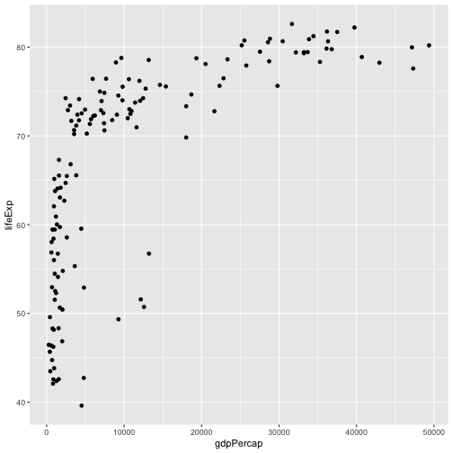

```r
gapminder %>%
  filter(year == 2007) %>%
  ggplot(aes(y=lifeExp,
             x=gdpPercap)) +
  geom_point()
```

### Change the x-axis to a log scale

The figure uses \( \log_2 \) with fancy labels (and has an error), but we will be content with simple labels.

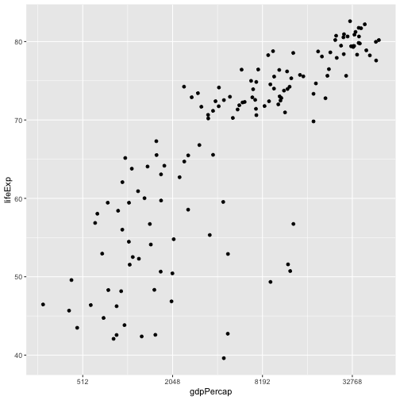

```r
gapminder %>%
  filter(year == 2007) %>%
  ggplot(aes(y=lifeExp,
             x=gdpPercap)) +
  geom_point() +
  scale_x_continuous(trans = "log2")
```

### Add axis labels and a title

Clean up the axis labels. I'll hide some of the code to make room on the screen.

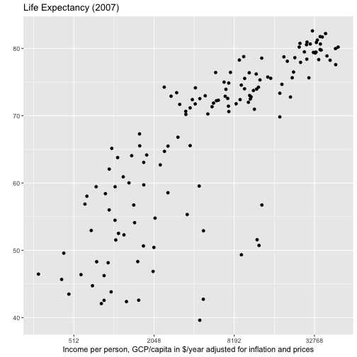

```r
gapminder %>%
  ggplot(aes(y=lifeExp,
             x=gdpPercap)) +
  ... +
  xlab("Income per person, GCP/capita in $/year adjusted for inflation and prices") +
  ylab("") +
  ggtitle("Life Expectancy (2007)")
```

### Add colour

We will use the continent name to pick colours.

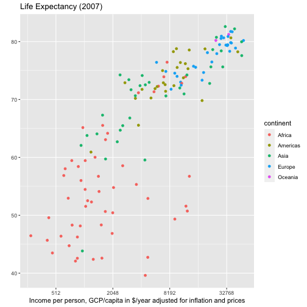

```r
gapminder %>%
  ggplot(aes(y=lifeExp,
             x=gdpPercap,
             color=continent)) +
  ...
```

### Make points transparent to highlight overlap

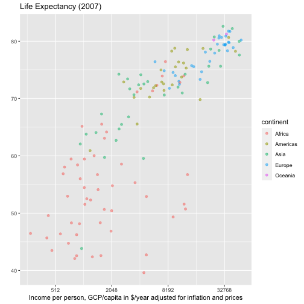

```r
  ggplot(aes(y=lifeExp,
             x=gdpPercap,
             color=continent)) +
  geom_point(alpha=0.5) +
  ...
```

### Add a black outline to each dot

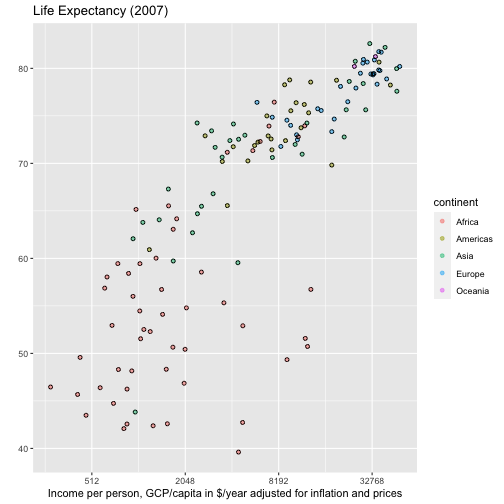

```r
  ggplot(aes(y=lifeExp,
             x=gdpPercap,
             color=continent)) +
  geom_point(alpha=0.5) +
  geom_point(shape=1, color="black") +
  ...
```

### Match the colour scale to the example

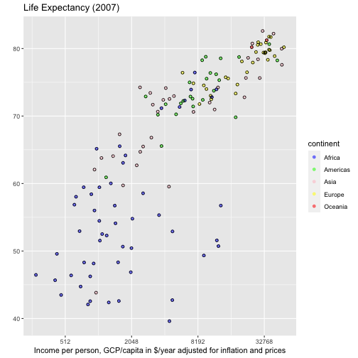

```r
  ggplot(aes(y=lifeExp,
             x=gdpPercap,
             color=continent)) +
  ... +
  scale_color_manual(values = c("blue", "green", "pink", "yellow", "red"))
```

### Make the points bigger

Scale the size of points using the population of each country.

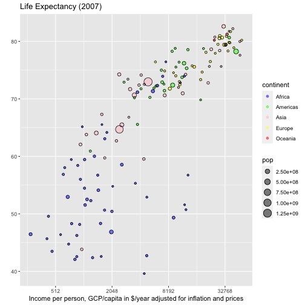

```r
  ggplot(aes(y=lifeExp,
             x=gdpPercap,
             color=continent,
             size=pop)) +
  ...
```

### Make the points bigger: Part 2

Make the points bigger by setting the maximum size of the points.

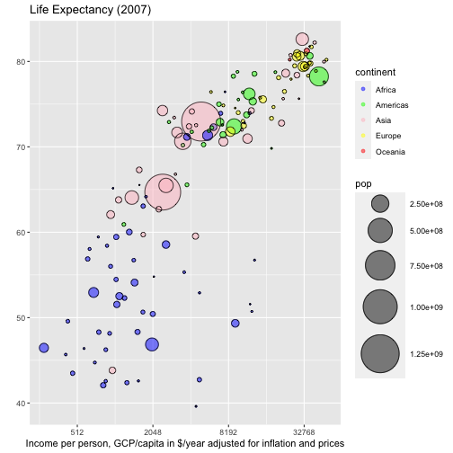

```r
  ggplot(aes(y=lifeExp,
             x=gdpPercap,
             color=continent,
             size=pop)) +
  ... +
  scale_size_area(max_size = 20)
```

### Hide the legend

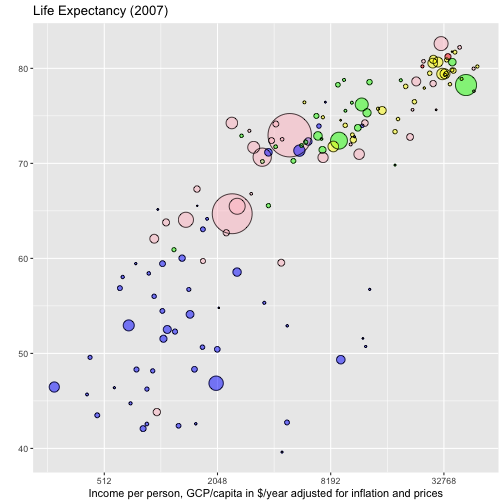

```r
  ggplot(aes(...)) +
  ... +
  theme(legend.position =
          "none")
```

### Draw a map for the inset

Get the map data and draw a map. Google a first example.

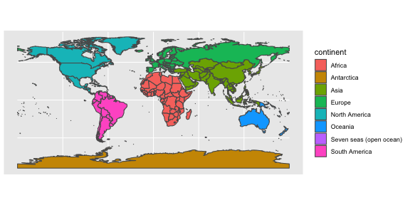

```r
world <- ne_countries(scale='medium',
      returnclass = 'sf')

world %>%
  ggplot() +
  geom_sf(aes(fill=continent))
```

### Remove Antarctica

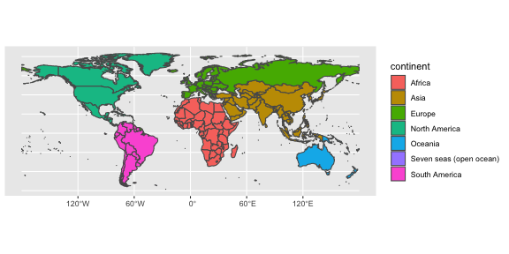

```r
world %>%
  filter(continent !=
           "Antarctica") %>%
  ggplot() +
  geom_sf(aes(fill=continent))
```

### Match the colours to the plot

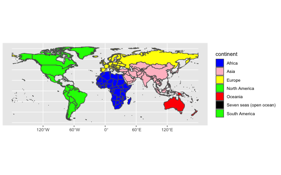

```r
world %>%
  ggplot() +
    scale_fill_manual(values =
          c("blue", "pink", "yellow",
            "green", "red", "black",
            "green" ))
```

### Remove outlines on countries and make colors transparent

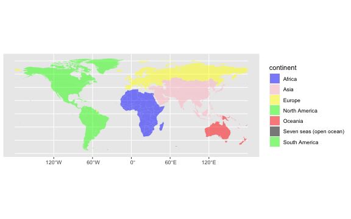

```r
world %>%
  ggplot() +
  geom_sf(aes(fill=continent),
          color=NA,
          alpha=0.5) +
  ...
```

### Remove the legend

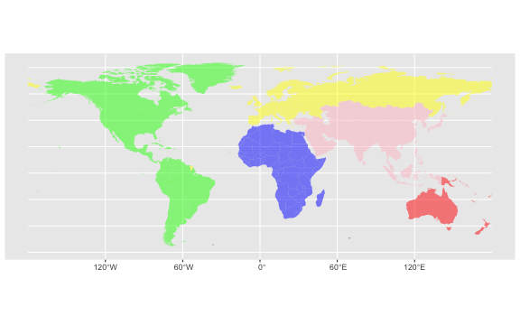

```r
world %>%
  ggplot() +
  ... +
  theme(legend.position = "none")
```

### Clean up the grid lines, white background

Lots of help from Google to figure this out!

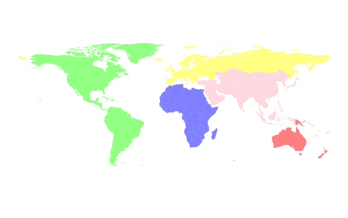

```r
world %>%
  ggplot() + ... +
    theme_bw() +
    theme(legend.position= "none",
      panel.border= element_rect(linetype=0),
      panel.grid= element_line(color=NA),
      panel.background= element_rect(fill=NA),
      plot.background= element_rect(fill=NA),
      axis.text.x= element_text(color=NA),
      axis.ticks.length= unit(0, "cm"))
```

### Store the map in an object for later use

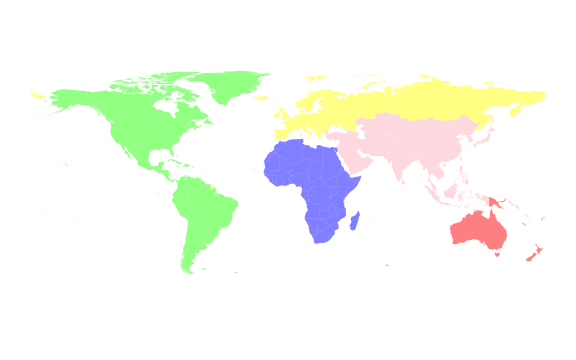

```r
world %>%
  ggplot() +
  ... -> world_map
print(world_map)
```

### Combine the plot and the map

And add a floating label for Canada.

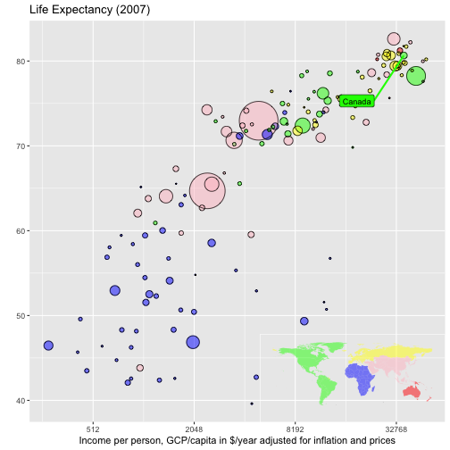

```r
ggplot(aes(y=lifeExp,
           x=gdpPercap)) +
  annotation_custom(grob=
    ggplotGrob(world_map),
    xmin=12.3,
    ymin=35, ymax=50 ) +

  geom_label_repel(aes(
          label=country),
      data = gapminder %>%
       filter(year ==2007,
        country=="Canada"),
    color="black",
    fill="green",
    segment.size=1,
    segment.color="green",
    box.padding=3) +
  ...
```

### Adjust the aspect ratio

Use the ratio of width (log units, log2(30000/300)) to height (80-40), scaled to be 1:2 for a wide plot.

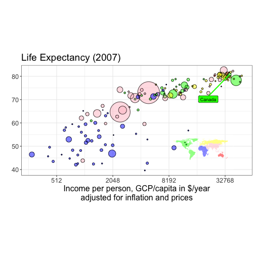

```r
gapminder %>%
  ggplot(aes(y=lifeExp,
             x=gdpPercap,
             color=continent,
             size=pop)) +
  ... +
  coord_fixed(ratio=(1/2)*
                log2(30000/300)/(80-40))
```

### How did we do?

[figure not shown]

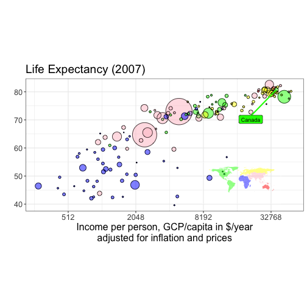

### Final code and plot

```r
gapminder %>% filter(year == 2007) %>%
  ggplot(aes(y=lifeExp, x=gdpPercap, color=continent, size=pop)) +
  geom_point(alpha=0.5) +
  geom_point(shape=1, color="black") +
  geom_label_repel(aes(label=country), data =
                     gapminder %>% filter(year ==2007,
                                          country=="Canada"),
                                   color="black", fill="green",
                   segment.size=1, segment.color="green",
                   box.padding=3) +
  xlab("Income per person, GCP/capita in $/year\nadjusted for inflation and prices") +
  ylab("") +
  theme_bw() +
  ggtitle("Life Expectancy (2007)") +
  scale_color_manual(values = c("blue", "green", "pink",
                                "yellow", "red")) +
  scale_size_area(max_size = 20) +
  annotation_custom(grob=ggplotGrob(world_map),
                  xmin=12.3, ymin=40, ymax=55 ) +
  scale_x_continuous(trans = "log2") +
  theme(legend.position = "none",
        text=element_text(size=16))  +
  coord_fixed(ratio=0.5*log2(30000/300)/(80-40)) -> final_plot
```

### Final plot

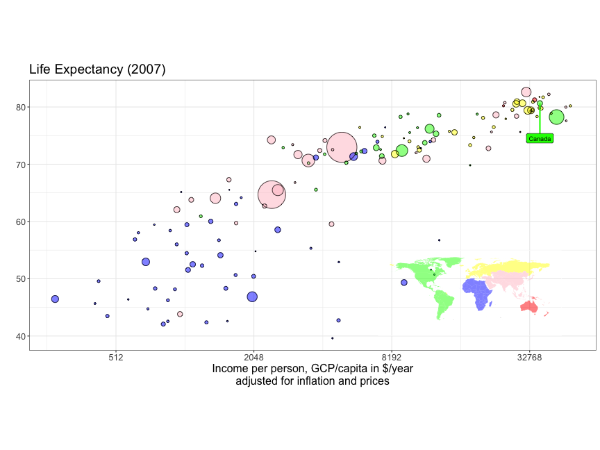

### Final map code

```r
world %>% filter(continent != "Antarctica") %>%
  ggplot() + geom_sf(aes(fill=continent), color=NA, alpha=0.5) +
    scale_fill_manual(values = c("blue", "pink", "yellow","green",
                                 "red", "black", "green" )) +
    theme_bw() + theme(legend.position = "none",
                     panel.border=element_rect(linetype=0),
                     panel.grid = element_line(color=NA),
                     panel.background = element_rect(fill=NA),
                     plot.background = element_rect(fill=NA),
                     axis.text.x = element_text(color=NA),
                     axis.ticks.length =  unit(0, "cm")) -> world_map
```

### Libraries used

```r
library(tidyverse)
library(gapminder)
library(ggrepel)
library(rnaturalearth)
library(rnaturalearthdata)
library(rgeos)
```